# Homework 4

**Submission:** To submit your homework, please share your GitHub repository with **stephaneguerrier**, **Yuming-Zhang** and **lionelvoirol** by the deadline (i.e. May 13th 2021 at noon). Please do not modify your homework after the deadline. We will grade the most recent (~ 12PM) portion of your RMarkdown file.

To start, create a **private** GitHub repository for your group, and name it **Intro_DS_HW4**. Once again, make sure to add **stephaneguerrier**, **Yuming-Zhang** and **lionelvoirol** as collaborators. This project **must** be done using GitHub and respect the following requirements:

**(1)** All members of the group must `commit` at least once.

**(2)** All commit messages must be reasonably `clear` and `meaningful`.

**(3)** Your GitHub repository must include at least one `issue` containing some form of TO DO list.

## Problem 1: Finding $\pi$ in `Rcpp`

In this exercise, we will revisit Problem 1 in HW3 to find $\pi$, but now you are asked to implement functions to estimate $\pi$ by Monte-Carlo simulations using `Rcpp` and potentially `RcppArmadillo`. Moreover, instead of the graphical display, in this problem we will focus on improving the execution time of this program by translating it in `C++`.

In HW3, you already programmed a function called `find_pi()`, where it generates `B` points based on which you estimate $\hat{\pi}$. Now you are asked to use the same approach to estimate $\hat{\pi}$, but instead, you should implement a function called `find_pi_cpp()` as well as other auxiliary functions in a separate `.cpp` file called `find_pi_rcpp.cpp`. You can then source this file in your HW4 R script using the following command:

```r
library(Rcpp)
library(RcppArmadillo)
sourceCpp("rcpp/find_pi_rcpp.cpp")
```

In your HW4 R script, you should also define the `find_pi()` function. You are allowed to directly refer to the solution of HW3. Once you have both `find_pi()` and `find_pi_cpp()` functions in your R script, you are asked to do the followings.

1. You should ensure that both functions return the same output when setting the same `seed`. To do so, use the following code (or your home-brewed similar one)

```r
## check same result

all_monte_carlo_size = 10^(0:6)
l_monte_carlo_size = length(all_monte_carlo_size)
for(monte_carlo_size_i in 1:l_monte_carlo_size){
  monte_carlo_size = all_monte_carlo_size[monte_carlo_size_i]
  # create res pi
  res_pi = vector("logical", length = 10)
  for(simu_i in seq(10)){
    seed_i = 123 + simu_i
    pi_r = find_pi(monte_carlo_size, seed=seed_i)
    pi_cpp = find_pi_cpp(monte_carlo_size, seed=seed_i)
    # test equality
    res_pi[simu_i] = all.equal(pi_r, pi_cpp)
  }
  # check if all elements are true
  print(all(res_pi))
}
```

and it should return

```r
[1] TRUE
[1] TRUE
[1] TRUE
[1] TRUE
[1] TRUE
[1] TRUE
[1] TRUE
```

which confirms that both functions return the same output when using the same `seed`.

2. You should illustrate graphically that both functions return the same values for different number of Monte-Carlo simulations. Moreover, the estimated $\hat{\pi}$ converges to the true value $\pi$.

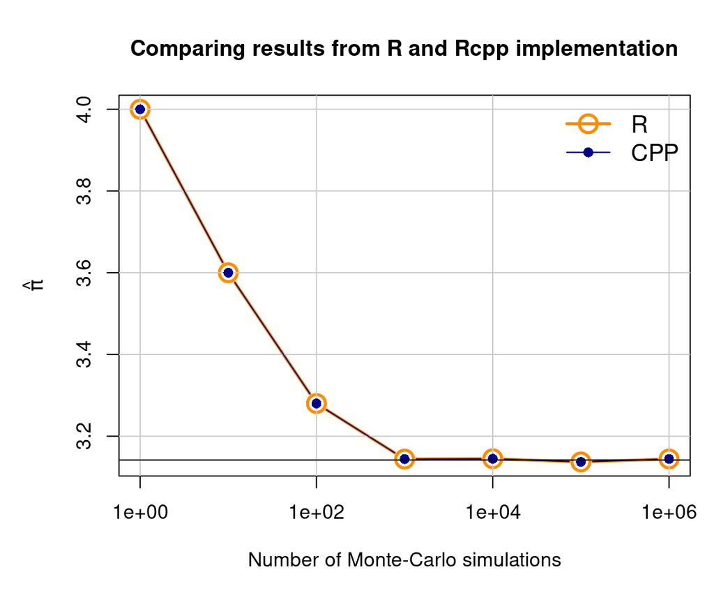

After you check the equality of outputs of both functions, you should perform a comparison of the execution time of these two functions for different number of Monte-Carlo simulations.

3. The first comparison required is to perform a benchmark of the execution time of these functions and represent the results from this experiment in a table. To do so, use the `microbenchmark` R package. You should obtain and present a similar output to the following when considering $10^5$ Monte-Carlo simulations, setting the parameter `times` (Number of times the expression is evaluated) equal to `100` and considering seconds as the unit for the execution time.

| expr | min | lq | mean | median | uq | max | neval | cld |
| --- | --- | --- | --- | --- | --- | --- | --- | --- |
| find_pi(B = monte_carlo_size, seed = 123) | 0.1210807 | 0.1300759 | 0.1409110 | 0.1336658 | 0.1378999 | 0.3800180 | 100 | b |
| find_pi_cpp(B = monte_carlo_size, seed = 123) | 0.0029236 | 0.0030580 | 0.0034233 | 0.0031955 | 0.0037668 | 0.0055023 | 100 | a |

These results summarise how long each query took: the minimum (`min`), lower and upper quartiles (`lq` and `uq`, respectively) and the mean, median and maximum, for each of the number of evaluations (`neval`, with the default value of 100 used in this case). `cld` reports the relative rank of each row in the form of ‘compact letter display’

4. The second comparison required is to produce the following graph, which compares the performance of both functions for different number of Monte-Carlo simulations.

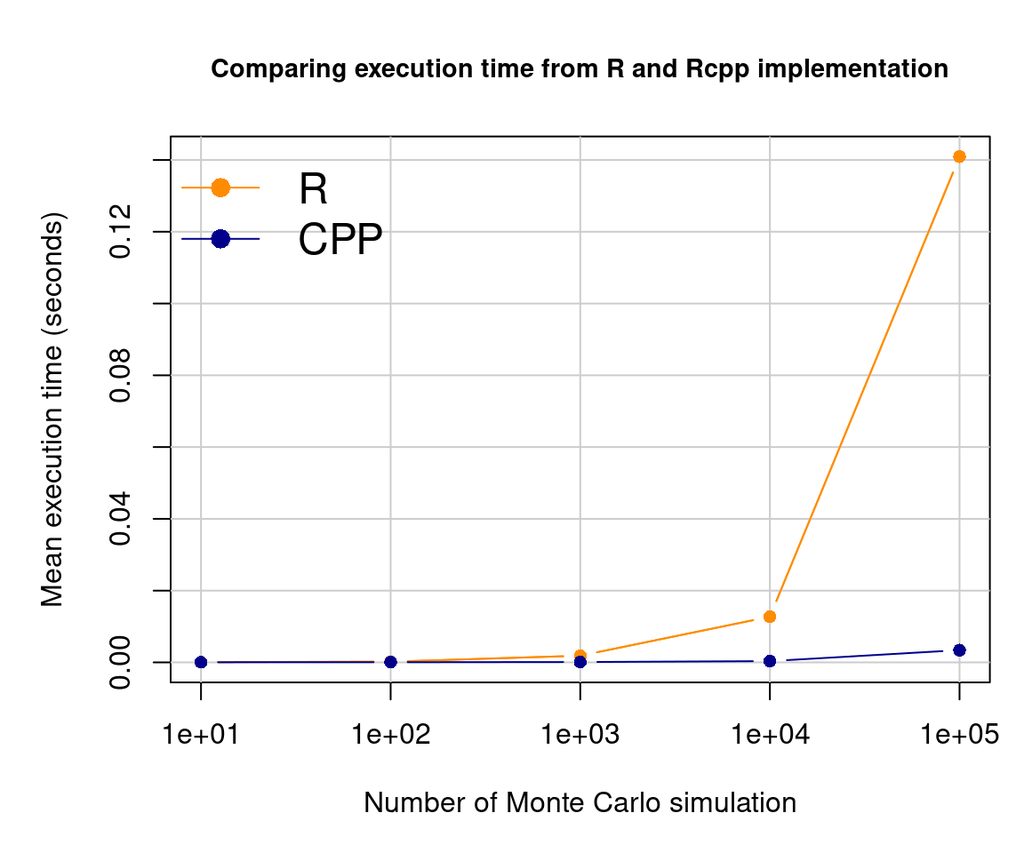

We suggest that you can refer to the following reference in terms of how to rewrite functions in R using `Rcpp` and `RcppArmadillo`:

- [Rcpp for everyone](https://teuder.github.io/rcpp4everyone_en/)
- [Armadillo documentation](http://arma.sourceforge.net/docs.html)
- [Advanced R (Rcpp section)](http://adv-r.had.co.nz/Rcpp.html)

## Hints

Here is an example code on how to generate a random matrix of uniform distributed random variable of dimensions `n` by `m`.

```r
library(Rcpp)
cppFunction('
NumericMatrix random_unif_mat_cpp(int n, int m) {
       NumericVector v = runif(n*m);
       return NumericMatrix(n, m, v.begin()); }

')
```

```r
random_unif_mat_cpp(2,3)
```

```
##           [,1]      [,2]      [,3]
## [1,] 0.4355315 0.2691077 0.6246276
## [2,] 0.2022619 0.3326712 0.2881642
```

**Warning:** Be careful that index starts from 0 in `c++`, whereas in R index starts from 1!